# 2nd Rough Analysis

Mariko NAKAGAWA

2022-04-28

### Preprocessing of Raw Reads

#### programs used

fasterq-dump: sra-tools

fastq_quality_filter: FASTX-Toolkit

fastx_trimmer: FASTX-Toolkit

a perl program to discard unpaired reads: https://www.biostars.org/p/56171/

#### commands

fasterq-dump [RUN ID]

fastq_quality_filter -q 30 -p 70 -i [RUN ID]_1.fastq -o [RUN ID]_1_filtered.fastq

fastq_quality_filter -q 30 -p 70 -i [RUN ID]_2.fastq -o [RUN ID]_2_filtered.fastq

fastx_trimmer -i [RUN ID]_1_filtered.fastq -o [RUN ID]_1_filtered_trimmed.fastq

fastx_trimmer -i [RUN ID]_2_filtered.fastq -o [RUN ID]_2_filtered_trimmed.fastq

perl removeUnpairedReads.pl [RUN ID]_1_filtered_trimmed.fastq [RUN ID]_2_filtered_trimmed.fastq

### Get the Intron Length Distribution from the 1st Rough Analysis

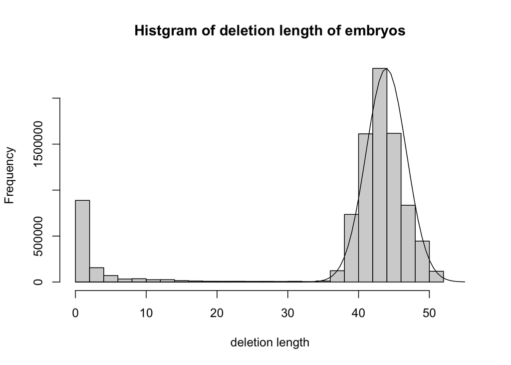

```
## [1] 43.91197
```

```
## [1] 2.857471
```

mean of ln(intron length), and standard deviation of ln(intron length)

meanlog=3.7800838, stdlog=0.0647753

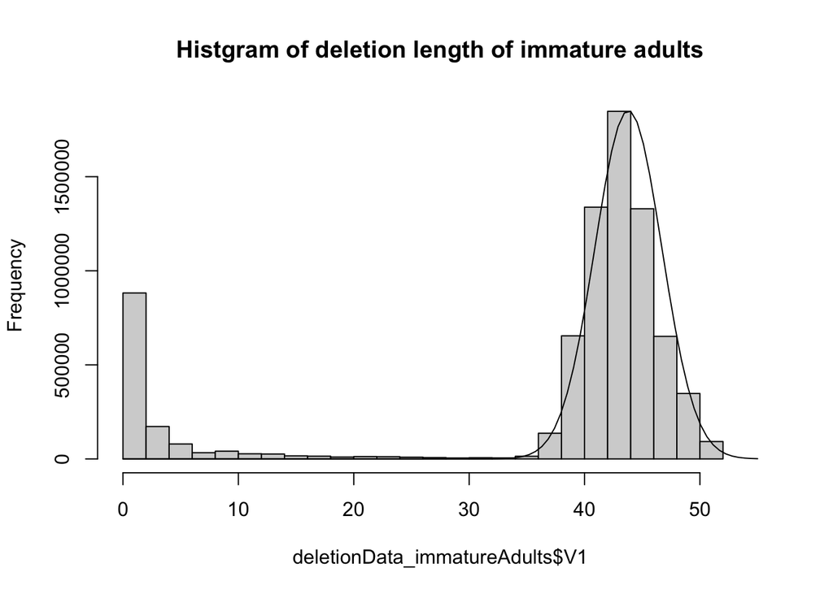

```
## [1] 43.79673
```

```
## [1] 2.901346
```

mean of ln(intron length), and stabdard deviation of ln(intron length)

meanlog=3.7773763, stdlog=0.066022

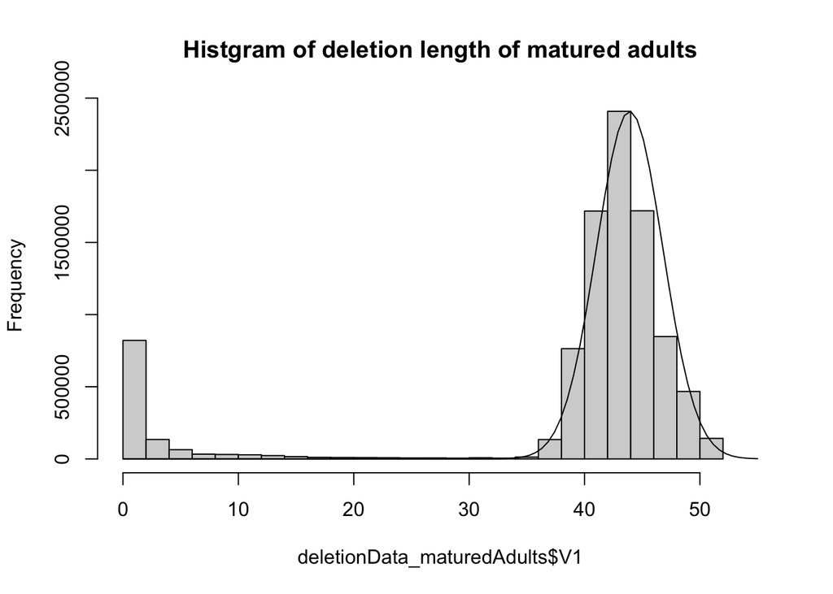

```
## [1] 43.90924
```

```
## [1] 2.877285
```

mean of ln(intron length), and standard deviation of ln(intron length)

meanlog=3.7799933, stdlog=0.0652033

### Alignment

#### LAST Commands

cat [RUN ID]_1_filtered_trimmed_sorted.fastq [RUN ID]_2_filtered_trimmed_sorted.fastq > [RUN ID]_filtered_trimmed_sorted.fastq

last-train -Q0 OikopleuraDB [RUN ID]_filtered_trimmed_sorted.fastq > trainOikopleura.out

lastal -D10 -p trainOikopleura.out [RUN ID]_filtered_trimmed_sorted.fastq | last-split -d2 -M3.78 -S0.065 -g OikopleuraDB > lastsplitOikopleura.maf

### Deletion Distribution

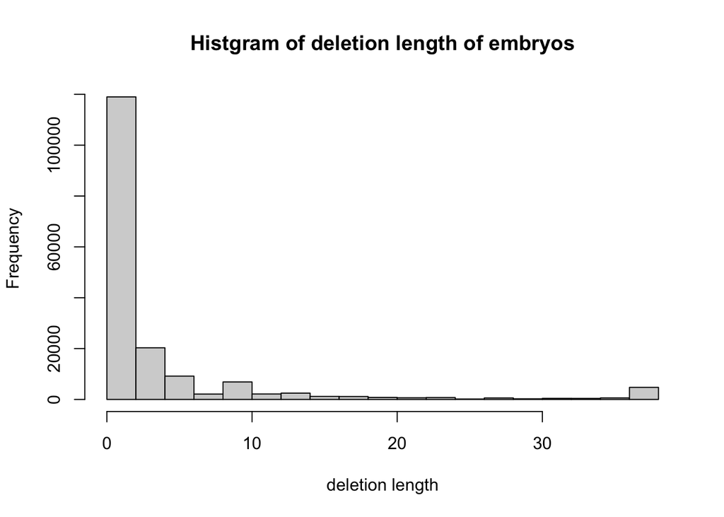

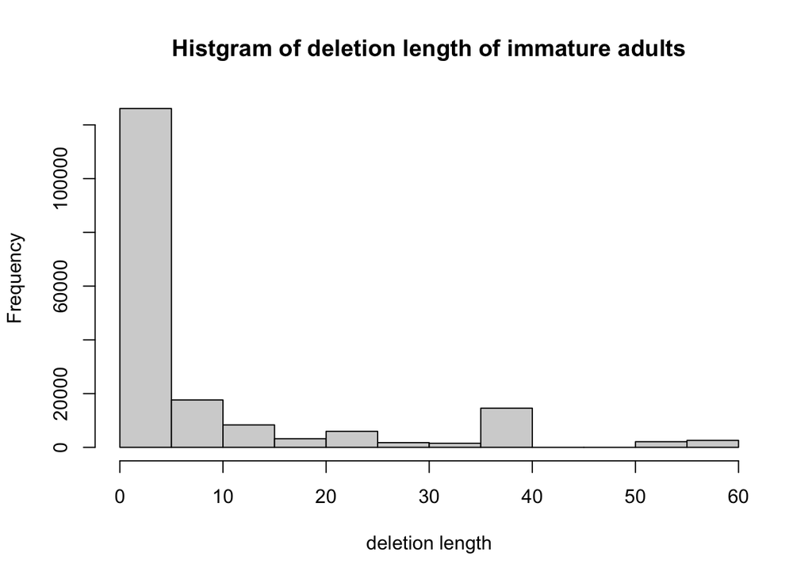

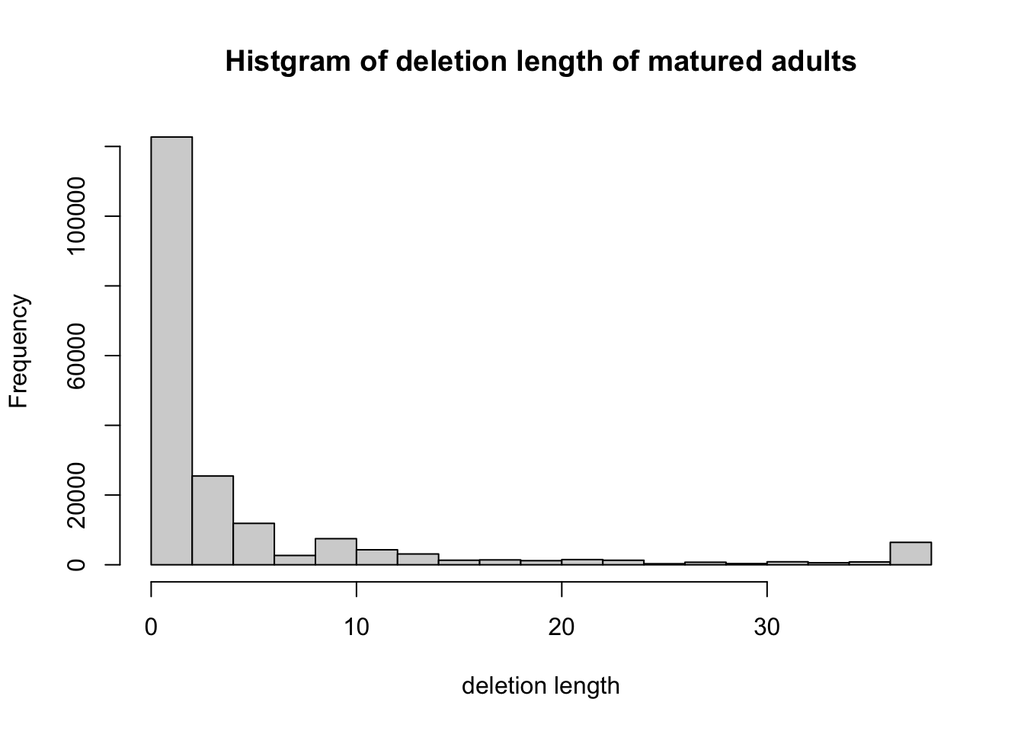

The graph of embryos and matured adults look almost identical. Somehow, there is a small peak in the graph of immature adults.

### Splicing Signals

I discarded data whose donor and acceptor are unknown.

I also discarded data in which reads have inserted sequence between aligned regions.

The number of splicing signals detected are

- embryos: 1286
- immature adults: 1307
- matured adults: 1230

I extracted top 10 splicing signals. The orders of top 10 splicing signals are the same in embryos and matured adults.

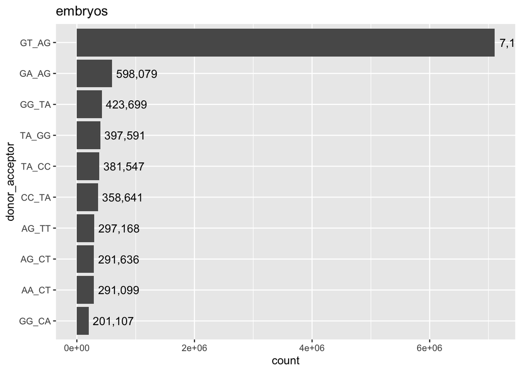

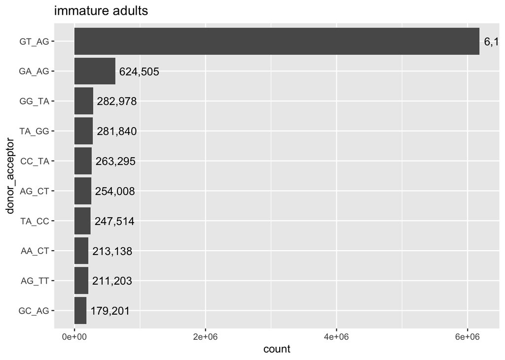

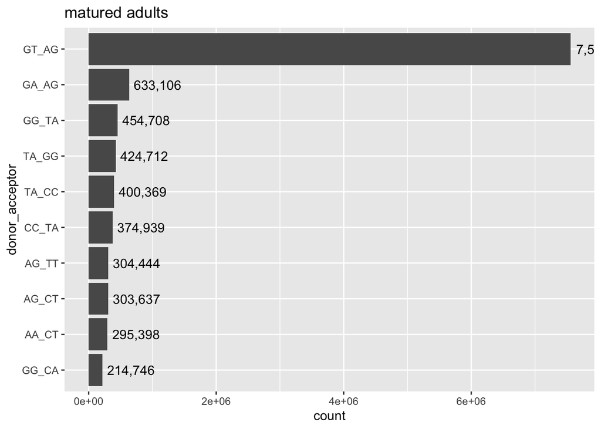

The number of GT_AG splicing signals

- embryos: 7101419
- immature adults: 6177990
- mature adults: 7554324

The percentage of non-canonical (non GT_AG, CT_AC) splicing signals

- embryos:43.1999404 %
- immature adults: 33.3258013 %
- matured adults: 42.3467032 %

↑ I counted

- the same junction mutiple times (= the number of reads crossing the junction)
- the a-little-bit-shifted junctions as different junctions